# **Ren rulling langs krum bane**

### W. Aarland, N. Aatif, A. Slåkvik, F. Bjerk

## Sammendrag

For å sammenligne teori og praksis kan man rulle en kule langs en bane og måle sluttfarten. Gjennom analyseprogrammet "Tracker" og filming av kulen, ble slutthastigheten målt til 1,380 $\pm$ 0,025 $m/s$. Ved å anvende teori ble sluttfarten beregnet til å være $1,483$ $m/s$, som avviker noe fra målingen. Det kan være på grunn av ujevnheter i banen, monteringsfeil eller tap av mekanisk energi i form av luftmotstand.

## Introduksjon

Året er 1687 [1], og Sir Isaac Newton har nylig publisert en bok som skal revolusjonere fysikkens verden for alltid. *Philosophiæ naturalis principia mathematica* innholder de kjente Newtons bevegelseslover. Dette er fundamentale lover vi ikke hadde klart oss uten ved gjennomførelse av dette eksperimentet. Vi tar steget videre og vil teste teori i praksis ved forsøk av rulling på skråplan. Forsøket består av et skråplan, med åtte varierende punkter for høyde, og en kule. Målet med forsøket er, ved å estimere posisjonen og hastigheten til kula, å finne avviket mellom virkeligheten og det teoretiske estimatet.

## Teori

Den totale mekaniske energien for kula er bevart: $E = K + U$, der $K$ er kinetisk energi, og $U$ er potensiell energi. Total kinetisk energi, gitt at kula ruller rent, er beskrevet av \begin{equation} K = \frac{1}{2}Mv² + \frac{1}{2}cMv² = \frac{(1 + c)Mv²}{2}, \tag{1} \end{equation} der $c = \frac{2}{5}$; $M$ er kulas masse; $R$ er kulas radius, altså avstanden mellom CM (massepunktet) og kontaktpunktet mellom kula og banen; og $v$ er kulas hastighet. Den potensielle energien til kula er gitt av \begin{equation} U = Mgy(x), \tag{2} \end{equation} der $g$ er tyngdeakselerasjonen og $y(x)$ er baneformen som funksjon av x. Ved energibevarelse får vi da at hastigheten til kula er gitt av \begin{equation} v(x) = \sqrt{\frac{10g\Delta y(x)}{7}}, \tag{3} \end{equation} der $\Delta y(x)=y_0 - y(x)$, altså kulas fall fra $y_0$ til en vilkårlig høyde $y(x)$. Videre er hastigheten i x-retning gitt av \begin{equation} v_x = cos(\beta), \tag{4} \end{equation} der $\beta = arctan(dy/dx)$ er helningsvinkelen til banen i x. Ved energibevarelse og $dt = \frac{dx}{v_x}$ kan tidsutviklingen regnes ut av \begin{equation} \Delta t_n = \frac{\Delta x_n}{\langle v_x \rangle _n} = \frac{2\Delta x_n}{v_{x,n-1} + v_{x,n}}, \tag{5} \end{equation} der $\langle v_x \rangle _n$ er gjennomsnittshastigheten i x-retning på intervall $n$, og $\Delta x_n = x_n - x_{n-1}$ er ett konstant steg.

[figure not shown]

**Figur 1**: Vedlagt er en tegning med krefter over når ballen ruller nedover, der $f$ er friksjonskraften, $G$ er tyngeakselerasjonen, $N$ er normalkraften, $a$ er akselerasjonen og $a_{⊥}$ er sentripentalakselerasjonen.

Ved å bruke Newtons 2. lov normalt på banen, der $Mgcos(\beta) < 0$ og $N > 0$, oppnås formelen \begin{equation} N-Mgcos(\beta)=Ma_⊥ => N = M(gcos(\beta) + a_⊥), \tag{7} \end{equation} På figuren krummer banen ned, noe som gjør at $G > N$ og $a_⊥ > 0$. Videre ved Newtons 2.lov for translasjon kan friksjonskraften $f$ regnes ut \begin{equation} \tag{8} f = \frac{2Mgsin(\beta)}{7} \end{equation} For at kravet om ren rulling skal være oppfylt, må friksjonskraften $f$ være statisk. Ren rulling innebærer at kulen ikke glir mot underlaget. For at dette skal være oppfylt må $|\frac{f_{max}}{N}|<\mu _s$, der $\mu _s$ er friksjonskoeffisienten mellom kula og underlaget [2].

## Metode

```
Laboppsett
```

Laboppsettet består av en bane som kulen skal rulle gjennom og et kamera som filmer forsøket, som vist i figur 2. Banen er laget av fleksibel plastikk og er festet i åtte justerbare punkter. Høyden til disse punktene må velges for å unngå at ballen stopper underveis og at andre feilkilder oppstår, som sluring eller hopp. Målinger av festepunktene er vist i tabell 1. Kameraet settes opp 4 meter unna banen for å unngå dybde-forvrengning i bildet, og filmer i 720p, 30fps for nøyaktig måling med minimalt "motion-blur".

```
Gjennomføring
```

Gjennomføringen av forsøket gjøres ved at kulen plasseres ved første festepunkt på banen og slippes slik at den triller uforstyrret gjennom hele banen. Dette gjøres totalt 10 ganger slik at eventuelle målefeil kan minimeres. Programmet "Tracker" sporer kulebanen over tid slik at de ønskede størrelsene kan regnes ut.

```
Numerisk metode
```

| Festepunkt | y [m] |
| --- | --- |
| 1 | 0,293 |
| 2 | 0,249 |
| 3 | 0,189 |
| 4 | 0,222 |
| 5 | 0,197 |
| 6 | 0,159 |
| 7 | 0,153 |
| 8 | 0,136 |

**Tabell 1:** Festepunktene og deres høyder over bakkenivå.

[figure not shown]

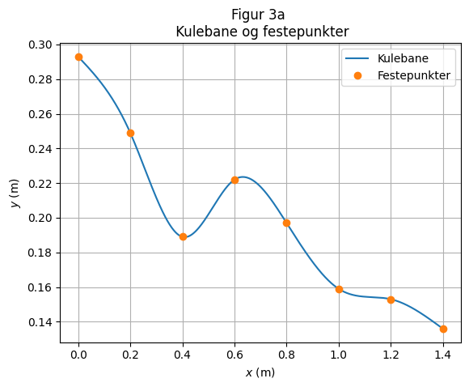

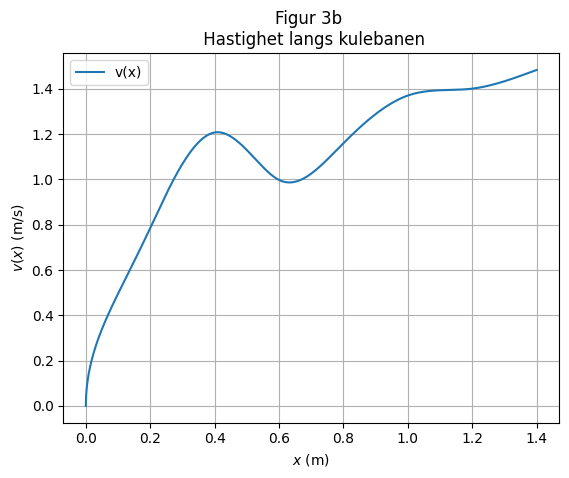

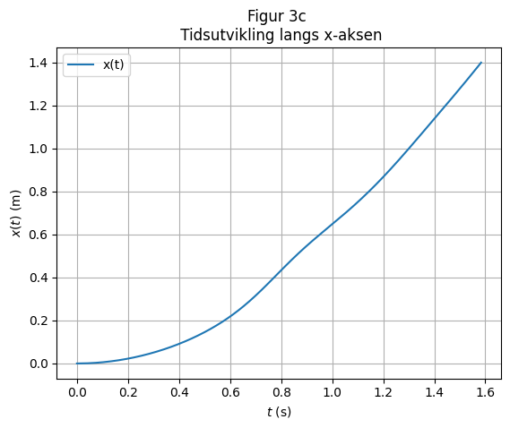

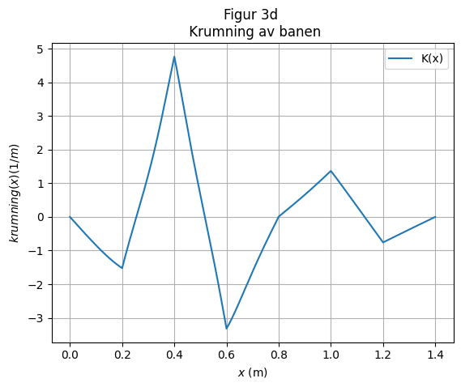

```python
import numpy as np
from scipy.interpolate import CubicSpline
import matplotlib.pyplot as plt

"""*Konstanter*"""
gravity = 9.81
c = 2/5 # c=2/5 for en kule

"""*Koordinater til banens festepunkter*"""

y_heights = [0.293,0.249,0.189,0.222,0.197,0.159,0.153,0.136]
#Høydene vi valgte ut (fra figur 2)
xfast = np.arange(0, 1.401, 0.2)
yfast = np.asarray(y_heights)

"""*Banen som går gjennom fetsepunktene*"""

cs = CubicSpline(xfast, yfast, bc_type = 'natural')
Nx = 1401 #Lengden til x, brukes senere
dx = 0.001
x = np.arange(0, Nx /1000, dx)
y = cs(x)
dy = cs(x,1)
d2y = cs(x,2)

"""*Numerisk fart langs banen*"""
def v_x():
    # cs(x) returns y(x)
    return np.sqrt((2*gravity*(y[0]-y)) / (1+c))

def v():
    return np.sqrt((10*gravity*(y[0]-y)) / 7)

"""*Numerisk metode for tidsutvikling langs x-aksen*"""
def numeric_method():
    # returnerer en tabell med 1401 verdier for y(x)
    t_n = np.zeros(Nx)

    for i in range(1, Nx):
        t_n[i] = t_n[i-1] + (2 * dx) / (v_x()[i-1] + v_x()[i])
    return t_n

"""*Krumning til kulebanen*"""
def krumning():
    # returnerer krumningsradiusen til banen i punktet x
    return d2y / (1 + dy**2)**(3/2)


"""*Plotting av banen og festepunkter*"""
plt.plot(x,y, label = "Kulebane")
plt.plot(xfast,yfast, "o", label = "Festepunkter")
plt.xlabel("$x$ (m)")
plt.ylabel("$y$ (m)")
plt.grid()
plt.title("Figur 3a \n Kulebane og festepunkter")
plt.legend()
plt.show()

"""*Plotting av v(x)*"""
figHastighet = plt.figure('v(x)')
plt.title('Figur 3b \n Hastighet langs kulebanen')
plt.plot(x, v(), label='v(x)')
plt.xlabel('$x$ (m)')
plt.ylabel('$v(x)$ (m/s)')
plt.grid()
plt.legend()
plt.show()

"""*Plotting av x(t)*"""
plt.title('Figur 3c \n Tidsutvikling langs x-aksen')
plt.plot(numeric_method(), x, label="x(t)")
plt.xlabel('$t$ (s)')
plt.ylabel('$x (t)$ (m)')
plt.grid()
plt.legend()
plt.show()

"""*Plotting av krumning*"""
plt.title("Figur 3d \n Krumning av banen")
plt.plot (x,krumning(), label="K(x)")
plt.xlabel("$x$ (m)")
plt.ylabel("$krumning(x) (1/m)$")
plt.grid()
plt.legend()
plt.show()
```

## Resultater

Den teoretiske baneformen som ble valgt er vist over, og er grunnlaget for de teoretiske utregningene. Dette sammenligner vi med målingene vi fikk fra Tracker.

Vi antar at kulen har en uniform massefordeling (derav c = 2/5), radius på 1.1 cm, og en masse på 31 gram.

```python
"""*Konstanter*"""
masse = 0.031 # kg for kulen
radius = 0.011 # m for kulen
N = 10 #Antall målinger

"""#Funksjoner#"""
#Plot funksjon
def plot(figName, figTitle, xLabel, yLabel, x_values, y_values, graphLabel=""):
    figName = plt.figure()
    plt.plot(x_values, y_values, label= graphLabel)
    plt.title(figTitle)
    plt.xlabel(xLabel)
    plt.ylabel(yLabel)
    plt.legend()
    plt.grid()
    plt.show()

#Henter ut data fra baneverdiene
def conv(x):
    return x.replace(",", ".").encode()

#data = [t,x,y,v]. For å få t -> data[:,0] osv
def getData(filename):
    # Returnerer en matrise med data fra filen.
    # Hvor kolonnene er tid, x-pos, y-pos, og velocity
    # data = [t, x, y, v]. For å få y -> data[:,2], for å få x -> data[:,1]
    return np.genfromtxt((conv(x) for x in open(filename)), dtype=float, skip_header=2, delimiter="\t", usemask=True)
```

Den teoretiske hastigheten, og de målte hastighetene med hensyn på tid kan vi se på grafen under. Vi ser at de målte verdiene er veldig lik den teoretiske.

```
Numerisk sluttfart: 1.4833215622860934
```

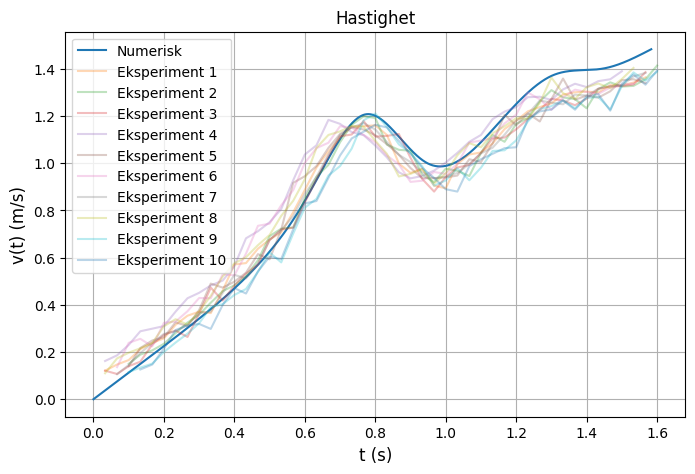

```python
plt.figure("Tittel", figsize = (8,5))
plt.plot(numeric_method(), v_x(), label = "Numerisk")
print(f"Numerisk sluttfart: {v_x()[-1]}")

gj_v = 0
for i in range(1, N + 1):
    data = getData(f"Baneverdier/baneverdier{i}.txt")

    t_expr = data[:,0]
    x_expr = data[:,1]
    y_expr = data[:,2]
    v_expr = data[:,3]

    #Summen av alle sluttfartene
    gj_v += v_expr[-2]
    #Plotter alt
    plt.plot(t_expr, v_expr, label = f"Eksperiment {i}", alpha = 0.3)
    plt.legend(loc = "upper left")
plt.title("Hastighet")
plt.xlabel("t (s)", fontsize = 12)
plt.ylabel("v(t) (m/s)", fontsize = 12)
plt.grid()
plt.show()
```

Under kan vi se beregnede verdier for gjennomsnittslig sluttfart, standardavvik, standardfeil og kinetisk energi.

```python
#Gjennomsnitts sluttfart
gj_v = gj_v/10

#Kinetisk energi
avg_E_k = 1/2 * masse * gj_v**2

#Standardavvik
temp = 0
for i in range(1, N + 1):
    data = getData(f"Baneverdier/baneverdier{i}.txt")

    v_expr = data[:,3]

    temp += (v_expr[-2]-gj_v)**2

s = np.sqrt(1/(N-1)*temp)

#Standardfeil
s_feil = s/np.sqrt(N)

print(f"Gjennomsnitts sluttfart med standardavvik: {gj_v:.3f} +- {s:.3f} m/s")
print(f"Standardfeil: {s_feil:.3f} m/s")
print(f"Kinetisk energi: {avg_E_k:.3f} J")


# """Returnere sluttfarten til kulen for alle 10 eksperimentene"""
# for i in range(1, 11):
#     data = getData(f"Baneverdier/baneverdier{i}.txt")
#     v_expr = data[:,3][-2]
#     print(f"Sluttfart for eksperiment {i}: {v_expr} m/s")
# #     print(f"{v_expr:.3f}")
```

```
Gjennomsnitts sluttfart med standardavvik: 1.380 +- 0.025 m/s
Standardfeil: 0.008 m/s
Kinetisk energi: 0.030 J
```

| Forsøk | $v$ [m/s] |
| --- | --- |
| 1 | 1,364 |
| 2 | 1,414 |
| 3 | 1,386 |
| 4 | 1,390 |
| 5 | 1,340 |
| 6 | 1,338 |
| 7 | 1,383 |
| 8 | 1,404 |
| 9 | 1,388 |
| 10 | 1,393 |
| $v_{avg}$ | 1,380 $\pm$ 0,025 |
| $v_{n}$ | 1.483 |

**Tabell 2:** Slutthastigheter fra hvert eksperiment, gjennomsnittlig slutthastighet med standardavvik, $v_{avg}$, og den teoretiske slutthastigheten, $v_{n}$.

## Diskusjon

Det er flere usikkerhetsfaktorer som kan påvirke eksperimentet, og resultatet. Det er muligheter for at kulen ikke starter i punktet $(x_0, y(x_0))$, og at kulen ikke starter med $v_0 = 0 m/s$. Gitt at $v_0 > 0 m/s$ vil dette medføre at sluttfarten på eksperimentet vil være større. Vi ser ut ifra målingene at $v_{avg} < v_{n}$, og vi kan dermed konkludere med at dette ikke vil forårsake avviket fra den teoretisk sluttfarten.

Den teoretisk modellen tar ikke hensyn til luftmotstanden, og tapet av mekanisk energi dette vil medføre. Det er vanskelig å modellere luftmostanden, men tapet av mekanisk energi vil påvirke sluttfarten til kulen, slik at sluttfarten blir lavere. Dette er fordi luftmostanden vil påføre arbeid i motsattt retning av bevegelsesretningen til kulen. I tillegg vil kulebanen også kunne ha innvirkninger på den mekaniske energien. Det er muligheten for at det er smuss, og andre uregelmessigheter i banen som kan gi økt friksjonskraft på kulen.

Baneoppsettet vil påvirke hele eksperminentet. Her er det muligheter for menneskelige feil ved montering, og oppsetting av banen. Det at de reelle festepunktene fravviker fra de teoretisk festepunktene gir en annen kulebane. Dette bil medføre at sluttfarten på kulen blir endret, i forhold til den numeriske.

Eksperimentet ble gjort men den antagelsen om at kulen har en uniform massefordeling, og radius. I realiteten stemmer den antagelsen ikke, og dette er noe som vil påvirke resultatet. Ved å øke $c$ vil den teoretiske sluttfarten minke, og dette er noe som kan stemme i realiteten. For at kulen skal ha en $c$ som gir $v_{avg} = v_{n}$ må $c \approx 0.62$. Dette er nok en økning i $c$ som er for stor, og som ikke vil stemme i realiteten.

## Konklusjon

Vi fant at den teoretiske sluttfarten var $v_{n} = 1.483 m/s$, og den eksperimentelle sluttfarten var $v_{avg} = 1.380 \pm 0,025 m/s$. Dette avviket kan komme av feilmonetering av banen i forhold til den teoretiske kulebanen, samt endring i mekanisk energi på grunn av luftmotstand, og eventuelt smuss i kulebanen. En annen årsak til avviket kan være ikke-uniform fordeling av kulens masse som vil påvirke konstanten $c$ som har direkte påvirkning til kulens totalenergi.

## Referanser

[1] Newton, I. (1934). Principia mathematica. Book III, Lemma V, Case, 1, 1687.

[2] J. A. Støvneng, Institutt for fysikk, NTNU: TFY41xx Fy- sikk: Labprosjekt Vår 2021. https://home.phys.ntnu.no/brukdef/undervisning/fyslab/files/labligninger.pdf, (sjekket 27.10.2022).